# Quiz_SwathiGanesan-Copy1

## Feature and Model Engineering Case for Machine Learning

#### Question 1: Load

```python
# import libraries
import polars as pl
import pandas as pd
import numpy as np
import json

import matplotlib.pyplot as plt
```

```python
# read each line of a JSON file as a separate JSON object
trans = pl.read_ndjson('transactions.txt')
# convert the Polars DataFrame to a pandas DataFrame
trans_df = trans.to_pandas()
```

```python
# taking a look at the data sample
trans_df.head()
```

|  | accountNumber | customerId | creditLimit | availableMoney | transactionDateTime | transactionAmount | merchantName | acqCountry | merchantCountryCode | posEntryMode | ... | echoBuffer | currentBalance | merchantCity | merchantState | merchantZip | cardPresent | posOnPremises | recurringAuthInd | expirationDateKeyInMatch | isFraud |
| --- | --- | --- | --- | --- | --- | --- | --- | --- | --- | --- | --- | --- | --- | --- | --- | --- | --- | --- | --- | --- | --- |
| 0 | 737265056 | 737265056 | 5000.0 | 5000.0 | 2016-08-13T14:27:32 | 98.55 | Uber | US | US | 02 | ... |  | 0.0 |  |  |  | False |  |  | False | False |
| 1 | 737265056 | 737265056 | 5000.0 | 5000.0 | 2016-10-11T05:05:54 | 74.51 | AMC #191138 | US | US | 09 | ... |  | 0.0 |  |  |  | True |  |  | False | False |
| 2 | 737265056 | 737265056 | 5000.0 | 5000.0 | 2016-11-08T09:18:39 | 7.47 | Play Store | US | US | 09 | ... |  | 0.0 |  |  |  | False |  |  | False | False |
| 3 | 737265056 | 737265056 | 5000.0 | 5000.0 | 2016-12-10T02:14:50 | 7.47 | Play Store | US | US | 09 | ... |  | 0.0 |  |  |  | False |  |  | False | False |
| 4 | 830329091 | 830329091 | 5000.0 | 5000.0 | 2016-03-24T21:04:46 | 71.18 | Tim Hortons #947751 | US | US | 02 | ... |  | 0.0 |  |  |  | True |  |  | False | False |

5 rows × 29 columns

```python
# describing the structure of the data. Number of records and fields in each record
trans_df.shape
```

```
(786363, 29)
```

The transactions dataframe has 786363 rows and 29 columns.

```python
trans_df.info()
```

```
<class 'pandas.core.frame.DataFrame'>
RangeIndex: 786363 entries, 0 to 786362
Data columns (total 29 columns):
 #   Column                    Non-Null Count   Dtype
---  ------                    --------------   -----
 0   accountNumber             786363 non-null  object
 1   customerId                786363 non-null  object
 2   creditLimit               786363 non-null  float64
 3   availableMoney            786363 non-null  float64
 4   transactionDateTime       786363 non-null  object
 5   transactionAmount         786363 non-null  float64
 6   merchantName              786363 non-null  object
 7   acqCountry                786363 non-null  object
 8   merchantCountryCode       786363 non-null  object
 9   posEntryMode              786363 non-null  object
```

[output cut: 21 more lines]

```python
# identified some entries are empty strings. replace empty strings with None
trans_df.replace('', None, inplace=True)
```

```python
# calculate the sum of missing values in each column
missing_values = trans_df.isna().sum()

# display the result
print(missing_values)
```

```
accountNumber                    0
customerId                       0
creditLimit                      0
availableMoney                   0
transactionDateTime              0
transactionAmount                0
merchantName                     0
acqCountry                    4562
merchantCountryCode            724
posEntryMode                  4054
posConditionCode               409
merchantCategoryCode             0
currentExpDate                   0
accountOpenDate                  0
dateOfLastAddressChange          0
cardCVV                          0
enteredCVV                       0
cardLast4Digits                  0
transactionType                698
echoBuffer                  786363
currentBalance                   0
merchantCity                786363
merchantState               786363
merchantZip                 786363
cardPresent                      0
posOnPremises               786363
recurringAuthInd            786363
expirationDateKeyInMatch         0
isFraud                          0
dtype: int64
```

We can see that 6 columns have all missing values and hence we can go ahead and drop these columns before proceeding. We do not have missing values in our target : isFraud

```python
# dropping columns where all rows are None
trans_df_clean = trans_df.dropna(axis=1, how='all')
trans_df_clean.shape
```

```
(786363, 23)
```

```python
# removing all nulls
trans_df_clean = trans_df_clean.dropna()
# reset the index inplace and drop the old index column
trans_df_clean.reset_index(drop=True, inplace=True)

trans_df_clean.shape
```

```
(776668, 23)
```

```python
# ensuring there are no nulls in the dataframe
sum(trans_df_clean.isna().sum())
```

```
0
```

```python
# providing some additional basic summary statistics for each field
trans_df_clean.describe()
```

|  | creditLimit | availableMoney | transactionAmount | currentBalance |
| --- | --- | --- | --- | --- |
| count | 776668.000000 | 776668.000000 | 776668.000000 | 776668.000000 |
| mean | 10756.182822 | 6247.583238 | 136.975808 | 4508.599584 |
| std | 11631.241047 | 8873.694052 | 147.697222 | 6457.248679 |
| min | 250.000000 | -1005.630000 | 0.000000 | 0.000000 |
| 25% | 5000.000000 | 1077.520000 | 33.650000 | 689.985000 |
| 50% | 7500.000000 | 3184.285000 | 87.890000 | 2451.715000 |
| 75% | 15000.000000 | 7500.000000 | 191.500000 | 5289.120000 |
| max | 50000.000000 | 50000.000000 | 2011.540000 | 47498.810000 |

```python
# count the number of unique values in each column
unique_counts = trans_df.nunique()

# display the result
print(unique_counts)
```

```
accountNumber                 5000
customerId                    5000
creditLimit                     10
availableMoney              521916
transactionDateTime         776637
transactionAmount            66038
merchantName                  2490
acqCountry                       4
merchantCountryCode              4
posEntryMode                     5
posConditionCode                 3
merchantCategoryCode            19
currentExpDate                 165
accountOpenDate               1820
dateOfLastAddressChange       2184
cardCVV                        899
enteredCVV                     976
cardLast4Digits               5246
transactionType                  3
echoBuffer                       0
currentBalance              487318
merchantCity                     0
merchantState                    0
merchantZip                      0
cardPresent                      2
posOnPremises                    0
recurringAuthInd                 0
expirationDateKeyInMatch         2
isFraud                          2
dtype: int64
```

Observations in the data by taking a look at the unique values:

- We have transaction information for 5000 users

```python
sorted(trans_df_clean['creditLimit'].unique())
```

```
[250.0,
 500.0,
 1000.0,
 2500.0,
 5000.0,
 7500.0,
 10000.0,
 15000.0,
 20000.0,
 50000.0]
```

- creditLimit is in the range of 250 to 50000 with 10 unique values

```python
trans_df_clean['acqCountry'].value_counts()
```

```
US     769620
MEX      3110
CAN      2406
PR       1532
Name: acqCountry, dtype: int64
```

- ~99% of the transactions are based in the US

```python
trans_df_clean['merchantCountryCode'].value_counts()
```

```
US     769621
MEX      3107
CAN      2399
PR       1541
Name: merchantCountryCode, dtype: int64
```

```python
trans_df_clean['posEntryMode'].value_counts()
```

```
05    312710
09    234776
02    194556
90     19437
80     15189
Name: posEntryMode, dtype: int64
```

```python
trans_df_clean['posConditionCode'].value_counts()
```

```
01    621279
08    147973
99      7416
Name: posConditionCode, dtype: int64
```

```python
trans_df_clean['merchantCategoryCode'].value_counts()
```

```
online_retail           199680
fastfood                110785
entertainment            79149
food                     74482
online_gifts             65424
rideshare                50510
hotels                   33669
fuel                     23631
subscriptions            22630
auto                     21345
health                   18854
personal care            18726
airline                  15188
mobileapps               14787
online_subscriptions     10928
furniture                 7347
food_delivery             6000
gym                       2183
cable/phone               1350
Name: merchantCategoryCode, dtype: int64
```

- ~40% of the transactions are on online_retail and fastfood

```python
trans_df_clean['transactionType'].value_counts()
```

```
PURCHASE                736636
REVERSAL                 20062
ADDRESS_VERIFICATION     19970
Name: transactionType, dtype: int64
```

- A good number of transactions are used for address_verification and they could be $0 transactions

```python
trans_df_clean['cardPresent'].value_counts()
```

```
False    428159
True     348509
Name: cardPresent, dtype: int64
```

```python
trans_df_clean['expirationDateKeyInMatch'].value_counts()
```

```
False    775642
True       1026
Name: expirationDateKeyInMatch, dtype: int64
```

```python
trans_df_clean['isFraud'].value_counts()
```

```
False    764702
True      11966
Name: isFraud, dtype: int64
```

- ~98.45% of transactions are non-fraudulant transactions

#### Question 2: Plot

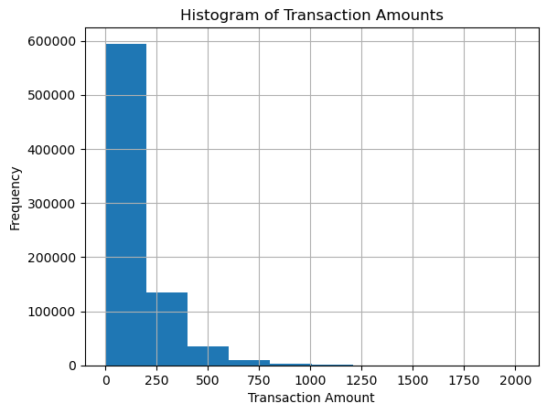

```python
# plotting a histogram of the transactionAmount column
trans_df_clean['transactionAmount'].hist()

# adding labels and title to the plot
plt.xlabel('Transaction Amount')
plt.ylabel('Frequency')
plt.title('Histogram of Transaction Amounts')

# displaying the plot
plt.show()
```

Based on the above graph, we can notice that the histogram of the processed transaction amounts is right-skewed (positively skewed). This suggests that there are a large number of low-value transactions and relatively fewer high-value transactions.

One possible hypothesis is that since the transactions represent retail sales and fastfood, the right skewness could due to the fact that most transactions are small purchases, while relatively few transactions are large purchases (subscriptions and electronics).

Another hypothesis is that the data includes fraudulent transactions, and the right skewness could be due to the fact that fraudulent transactions are typically small in value in order to avoid detection.

#### Question 3: Data Wrangling - Duplicate Transactions

For reversed transactions, we can identify them by finding pairs of transactions with the same accountNumber, transactionAmount, merchantName, and opposite transactionType values, where the first transaction is a purchase and the second transaction is a reversal.

For multi-swipe transactions, we can identify them by finding groups of transactions with the same accountNumber, transactionAmount, merchantName, and transactionDateTime values, where there are multiple transactions with the same values within a short time span. (assuming 2 minutes (120 seconds))

##### Identifying reversals

```python
trans_df_clean['transactionDateTime'] = pd.to_datetime(trans_df_clean['transactionDateTime'])
trans_df_clean['transactionDate'] = trans_df_clean['transactionDateTime'].dt.strftime('%m/%d/%Y')

# sorting the dataframe by accountNumber and transactionDateTime
trans_df_clean_utd = trans_df_clean.sort_values(['accountNumber', 'transactionDateTime'])

# creating a boolean mask for reversed transactions
reversal_mask = (trans_df_clean_utd['accountNumber'] == trans_df_clean_utd['accountNumber'].shift(1)) & \
       (trans_df_clean_utd['transactionAmount'] == trans_df_clean_utd['transactionAmount'].shift(1)) & \
       (trans_df_clean_utd['merchantName'] == trans_df_clean_utd['merchantName'].shift(1)) & \
       (trans_df_clean_utd['transactionDate'] == trans_df_clean_utd['transactionDate'].shift(1)) & \
       (trans_df_clean_utd['transactionType'] == 'REVERSAL') & \
       (trans_df_clean_utd['transactionType'].shift(1) == 'PURCHASE')

# updating the is_reversed column using boolean indexing
trans_df_clean_utd.loc[reversal_mask, 'is_reversed'] = True

# filling missing values with False
trans_df_clean_utd['is_reversed'] = trans_df_clean_utd['is_reversed'].fillna(False)
```

```python
trans_df_clean_utd.reset_index(drop=True, inplace=True)
trans_df_clean_utd.is_reversed.value_counts()
```

```
False    771239
True       5429
Name: is_reversed, dtype: int64
```

```python
reversed_transactions = trans_df_clean_utd[trans_df_clean_utd['is_reversed'] == True]
reversed_count = reversed_transactions['transactionAmount'].count()
reversed_total = reversed_transactions['transactionAmount'].sum()
print("Total number of reversed transactions: ", reversed_count)
print("Total dollar amount of reversed transactions: $", reversed_total)
```

```
Total number of reversed transactions:  5429
Total dollar amount of reversed transactions: $ 813878.5800000001
```

##### Identifying multi-swipes

```python
# sorting the dataframe by accountNumber and transactionDateTime
trans_df_clean_utd = trans_df_clean_utd.sort_values(['accountNumber', 'transactionDateTime'])

# creating a boolean mask for multi-swipe transactions
from datetime import datetime, timedelta
multi_swipe_mask = (trans_df_clean_utd['accountNumber'] == trans_df_clean_utd['accountNumber'].shift(1)) & \
                   (trans_df_clean_utd['transactionAmount'] == trans_df_clean_utd['transactionAmount'].shift(1)) & \
                   (trans_df_clean_utd['merchantName'] == trans_df_clean_utd['merchantName'].shift(1)) & \
                   (trans_df_clean_utd['transactionDate'] == trans_df_clean_utd['transactionDate'].shift(1)) & \
                   ((pd.to_datetime(trans_df_clean_utd['transactionDateTime']) - pd.to_datetime(trans_df_clean_utd['transactionDateTime'].shift(1))) < timedelta(seconds=120))

# updating the is_multi_swipe column using boolean indexing
trans_df_clean_utd.loc[multi_swipe_mask, 'is_multi_swipe'] = True

# filling missing values with False
trans_df_clean_utd['is_multi_swipe'] = trans_df_clean_utd['is_multi_swipe'].fillna(False)
```

```python
trans_df_clean_utd.reset_index(drop=True, inplace=True)
trans_df_clean_utd.is_multi_swipe.value_counts()
```

```
False    767947
True       8721
Name: is_multi_swipe, dtype: int64
```

```python
multi_swipe_transactions = trans_df_clean_utd[trans_df_clean_utd['is_multi_swipe'] == True]
multi_swipe_count = multi_swipe_transactions['transactionAmount'].count()
multi_swipe_total = multi_swipe_transactions['transactionAmount'].sum()
print("Total number of multi-swipe transactions: ", multi_swipe_count)
print("Total dollar amount of multi-swipe transactions: $", multi_swipe_total)
```

```
Total number of multi-swipe transactions:  8721
Total dollar amount of multi-swipe transactions: $ 1281263.7400000002
```

There are a few interesting things that can be inferred from the data regarding the reversed and multi-swipe transactions.

Firstly, the total number of reversed transactions and the total dollar amount for those transactions suggest that they are not rare occurrences. This may indicate that the merchants are not properly verifying transactions or there are issues with the payment system that are causing these transactions to occur.

Secondly, the total number of multi-swipe transactions and the total dollar amount for those transactions suggest that this is also a relatively common occurrence. This may be due to user error or issues with the payment system.

Overall, it may be worth investigating the cause of these types of transactions to identify any potential issues with the payment system or the merchants involved.

#### Question 4: Model

```python
# selecting relevant columns
df_selected = trans_df_clean_utd[['accountNumber', 'transactionAmount', 'transactionDateTime', 'merchantCategoryCode', 'transactionType',
                        'currentBalance', 'cardPresent',
                        'expirationDateKeyInMatch', 'is_reversed', 'is_multi_swipe', 'isFraud']]

# creating dummy variables for categorical features
df_selected = pd.get_dummies(df_selected, columns=['merchantCategoryCode', 'transactionType'])

# converting transactionDateTime to datetime object
df_selected['transactionDateTime'] = pd.to_datetime(df_selected['transactionDateTime'])

# calculating days since last transaction
df_selected['days_since_last_transaction'] = df_selected.groupby('accountNumber')['transactionDateTime'].diff().dt.days
df_selected['days_since_last_transaction'] = df_selected['days_since_last_transaction'].fillna(0)

df_selected = df_selected.drop(['accountNumber', 'transactionDateTime'], axis=1)

# converting boolean columns to integers (0s and 1s)
boolean_cols = ['cardPresent', 'expirationDateKeyInMatch', 'is_reversed', 'is_multi_swipe', 'isFraud']
df_selected[boolean_cols] = df_selected[boolean_cols].astype(int)

df_selected.info()
```

```
<class 'pandas.core.frame.DataFrame'>
RangeIndex: 776668 entries, 0 to 776667
Data columns (total 30 columns):
 #   Column                                     Non-Null Count   Dtype
---  ------                                     --------------   -----
 0   transactionAmount                          776668 non-null  float64
 1   currentBalance                             776668 non-null  float64
 2   cardPresent                                776668 non-null  int64
 3   expirationDateKeyInMatch                   776668 non-null  int64
 4   is_reversed                                776668 non-null  int64
 5   is_multi_swipe                             776668 non-null  int64
 6   isFraud                                    776668 non-null  int64
 7   merchantCategoryCode_airline               776668 non-null  uint8
 8   merchantCategoryCode_auto                  776668 non-null  uint8
 9   merchantCategoryCode_cable/phone           776668 non-null  uint8
```

[output cut: 22 more lines]

```python
from sklearn.model_selection import train_test_split
from sklearn.linear_model import LogisticRegression
from sklearn.metrics import classification_report


# splitting the data into training and testing sets
X_train, X_test, y_train, y_test = train_test_split(df_selected.drop("isFraud", axis=1), df_selected["isFraud"], test_size=0.2)

# training the logistic regression model
clf = LogisticRegression(random_state=42, max_iter=1000)
clf.fit(X_train, y_train)

# predicting on the testing data
y_pred = clf.predict(X_test)

# printing the classification report
print(classification_report(y_test, y_pred, zero_division=1))
```

```
              precision    recall  f1-score   support

           0       0.98      1.00      0.99    152869
           1       1.00      0.00      0.00      2465

    accuracy                           0.98    155334
   macro avg       0.99      0.50      0.50    155334
weighted avg       0.98      0.98      0.98    155334
```

```python
# Make predictions on the training set
y_train_pred = clf.predict(X_train)

# Print the classification report
print(classification_report(y_train, y_train_pred))
```

```
              precision    recall  f1-score   support

           0       0.98      1.00      0.99    611833
           1       0.00      0.00      0.00      9501

    accuracy                           0.98    621334
   macro avg       0.49      0.50      0.50    621334
weighted avg       0.97      0.98      0.98    621334
```

```python
from sklearn.model_selection import cross_val_score

# performing 5-fold cross-validation
scores = cross_val_score(clf, df_selected.drop("isFraud", axis=1), df_selected["isFraud"], cv=5)

# printing the mean and standard deviation of the cross-validation scores
print("Accuracy: %0.2f (+/- %0.2f)" % (scores.mean(), scores.std() * 2))
```

```
Accuracy: 0.98 (+/- 0.00)
```

```python
# get the absolute value of coefficients
coef_abs = np.abs(clf.coef_[0])

# create a dataframe to store feature names and coefficients
coef_df = pd.DataFrame({'feature': X_train.columns, 'coef': coef_abs})

# sort the dataframe by coefficient values
coef_df = coef_df.sort_values(by='coef', ascending=False)

# display the top 7 features
top7_features = coef_df.head(7)['feature'].values.tolist()
print("Top 7 features:")
for feature in top7_features:
    print("- {}".format(feature))
```

```
Top 7 features:
- transactionType_ADDRESS_VERIFICATION
- transactionType_REVERSAL
- transactionType_PURCHASE
- cardPresent
- merchantCategoryCode_fastfood
- merchantCategoryCode_health
- merchantCategoryCode_subscriptions
```

If more time was provided, we could do hyper parameter tuning to identify the best parameters. We could have tried different models and chosen the best model. We can do detailed EDA in order to identify and use the most important features.